# 2020 Victorian Newspapers Sentiment Analysis

**A NOTE ON SENTIMENT ANALYSIS**

Sentiment analysis is a type of natural language processing, a field of data science and statistics that involves analysing text. Specifically, sentiment analysis uses statistical methods to measure the perceived sentiment of written work. The type of sentiment analysis I used for this piece is quite well-established: it measures how positive or negative the tone of a body of text is. Because of the relative age of this kind of analysis and the technological strides that have occurred since, its results are widely accepted. Furthermore, I have used three different dictionaries (a list of words and the sentiments associated with them) to mitigate bias ingrained in these analytical tools. The final “Sentiment Score” of each article in the following visualisations is a moderated combination of scores yielded from those three dictionaries. Trendlines have been generated with a loess algorithm—locally estimated scatterplot smoothing—which takes local subdivisions of points to estimate a smooth trendline.

This piece analyses the weekday and weekend coverage of *The Age*, *The Australian Financial Review*, *The Herald Sun*, and *The Australian*. I had two main reasons that motivated this selection. Firstly, I selected two of Melbourne’s most popular newspapers, *The Age* and *The Herald Sun*, since Victoria went through two lockdowns to nix the coronavirus pandemic, the second of which was fiercely contested in politics and media, making for more interesting analysis. Secondly, collecting every article published by a masthead throughout the year is not a simple task—while this analysis could be improved by including articles from the ABC, *The Guardian*, SBS, and others, it would have taken too long to scrape them as well. Therefore, I settled to analyse the two Melbourne dailies and their proprietors’ more nationally-oriented papers, *The AFR* and *The Australian*.

**BLACK SUMMER**

The historic Black Summer bushfires started to garner national and international interest at the end of 2019 and continued into the opening months of 2020. The fires were concentrated in Australia’s east, from Queensland in the north and Victoria in the south.

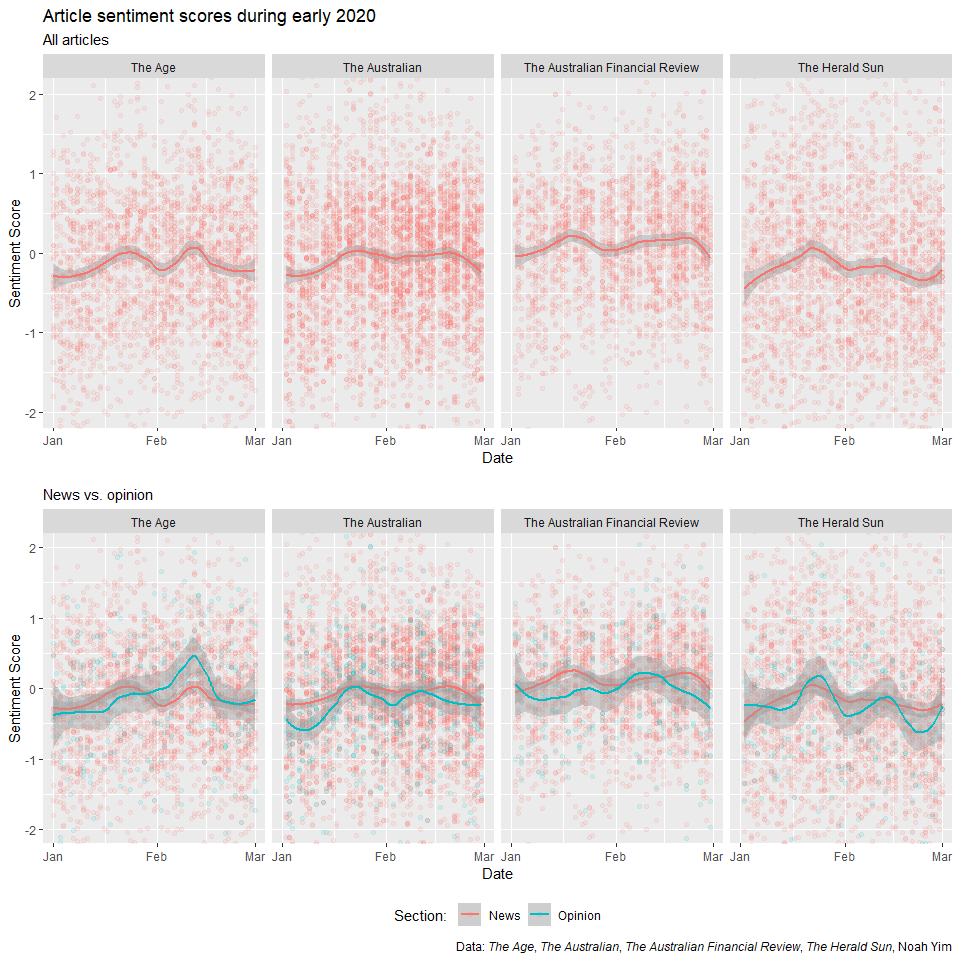

```r
Bushfire_df <- filter(df, as.Date("2020-01-01") <= Date & Date <= as.Date("2020-03-01"))

geom1 <- ggplot(Bushfire_df, aes(x = Date %>% as.Date(), y = mod_score)) +
  geom_point(alpha = 0.1, colour = "#F8766D") +
  geom_smooth(formula = y ~ x, method = "loess", span = 0.4, n = 200, colour = "#F8766D") +
  theme(legend.position = "bottom", plot.caption = element_markdown()) +
  coord_cartesian(ylim = c(-2, 2)) +
  scale_x_date(date_breaks = "1 month", date_labels = "%b") +
  labs(title = "Article sentiment scores during early 2020", subtitle = "All articles", caption = " ") +
  xlab("Date") +
  ylab("Sentiment Score") +
  facet_grid(. ~ Masthead)

geom2 <- ggplot(Bushfire_df, aes(x = Date %>% as.Date(), y = mod_score, colour = SectionSimple)) +
  geom_point(alpha = 0.1) +
  geom_smooth(formula = y ~ x, method = "loess", span = 0.4, n = 200) +
  theme(legend.position = "bottom", plot.caption = element_markdown()) +
  coord_cartesian(ylim = c(-2, 2)) +
  scale_x_date(date_breaks = "1 month", date_labels = "%b") +
  labs(subtitle = "News vs. opinion", caption = "Data: *The Age*, *The Australian*, *The Australian Financial Review*, *The Herald Sun*, Noah Yim", colour = "Section: ") +
  xlab("Date") +
  ylab("Sentiment Score") +
  facet_grid(. ~ Masthead)

grid.arrange(geom1, geom2)
```

In the visualisation above, each point represents an article, with its x-value representing the date on which it was published, and its y-value representing its moderated sentiment score. The grim start to the year was reflected in the tone of newspaper coverage: at year’s start, the sentiment scores are very low and tick up as the fires subside. It reaches a peak after mid-January, where rains extinguish some of the fires.

As one might expect, there is some discrepancy in the tone of news coverage and opinion. News tends to value neutral, unemotional language while opinion writers are given more free rein to express their ideas emotively. Accordingly, opinion pieces tended to have more extreme sentiment scores than news pieces during this time.

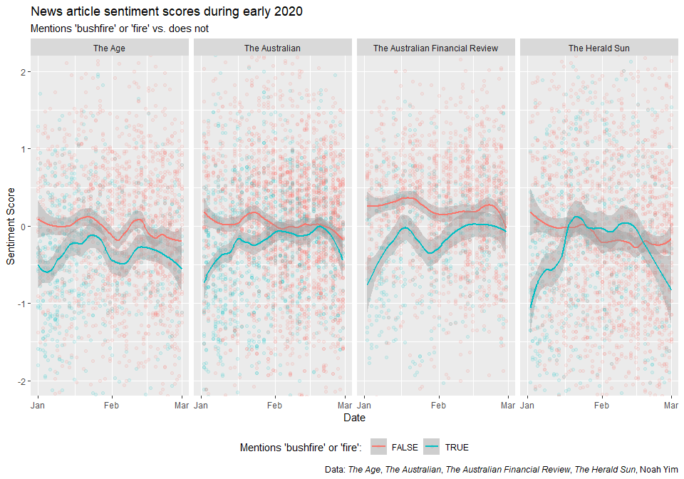

```r
Bushfire_t <- filter(Bushfire_df, str_detect(Text, "ushfire") | str_detect(Text, "fire"))
Bushfire_f <- filter(Bushfire_df, !(str_detect(Text, "ushfire") | str_detect(Text, "fire")))
Bushfire_t$Keyword = TRUE
Bushfire_f$Keyword = FALSE
Bushfire_tvf <- rbind(Bushfire_t, Bushfire_f)
rm(Bushfire_t, Bushfire_f)

geom <- ggplot(Bushfire_tvf %>% filter(SectionSimple == "News"), aes(x = Date %>% as.Date(), y = mod_score, colour = Keyword)) +
  geom_point(alpha = 0.1) +
  geom_smooth(formula = y ~ x, method = "loess", span = 0.4, n = 200) +
  theme(legend.position = "bottom", plot.caption = element_markdown()) +
  coord_cartesian(ylim = c(-2, 2)) +
  scale_x_date(date_breaks = "1 month", date_labels = "%b") +
  labs(title = "News article sentiment scores during early 2020", subtitle = "Mentions 'bushfire' or 'fire' vs. does not", caption = "Data: *The Age*, *The Australian*, *The Australian Financial Review*, *The Herald Sun*, Noah Yim", colour = "Mentions 'bushfire' or 'fire': ") +
  xlab("Date") +
  ylab("Sentiment Score") +
  facet_grid(. ~ Masthead)

geom
```

The visualisation above is of the news coverage (i.e. without editorials and opinions) across the four mastheads, comparing articles that included the terms ‘bushfire’ or ‘fire’ to those that didn’t. It shows that most of these papers’ news articles in early 2020 that didn’t mention bushfires were quite ambivalent while articles about bushfires were markedly negative. In other words, bushfire coverage was the driving force behind the negative tone of coverage at the start of the year. This is to be expected—bushfires are an inherently negative topic.

However, *The Herald Sun*’s tone of bushfire coverage bucked this trend, in that it was more positive than its coverage of other topics just after the 15th of January.

This is likely because of the “Australia Unites” series that *The Herald Sun*, along with other News Limited metro papers, published from the 19th of January to “celebrate the bushfire heroes, recognise the victims and identify recovery plans”. This involved headlines such as: “Parade push for firefighters”, “Bushfire heroes will get the gong”. While the series officially ended on the 26th of January, *The Herald Sun*’s articles that mentioned ‘bushfire’ or ‘fire’ stayed more positive than articles that didn’t for about a month afterward, primarily as a product of increasingly negative coverage of non-bushfire news.

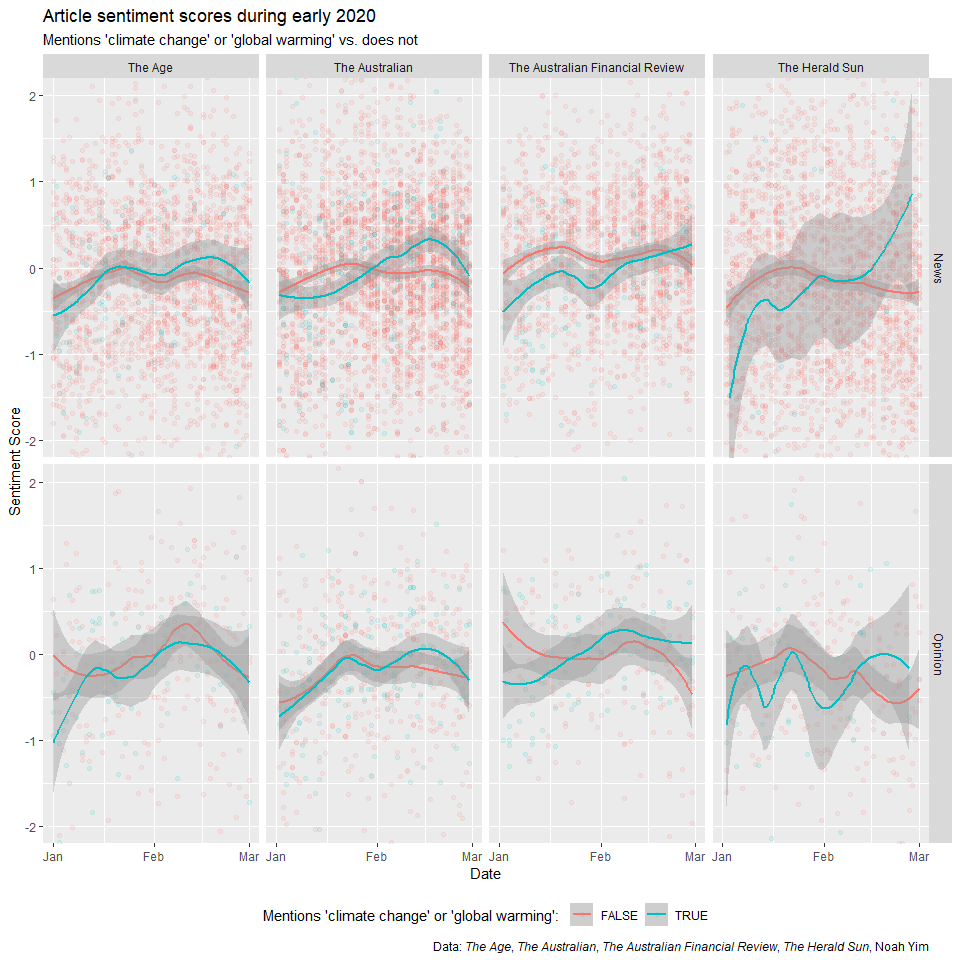

```r
CC_t <- filter(Bushfire_df, str_detect(Text, "limate change") | str_detect(Text, "lobal warming") | str_detect(Text, "warming"))
CC_f <- filter(Bushfire_df, !(str_detect(Text, "limate change") | str_detect(Text, "lobal warming") | str_detect(Text, "warming")))
CC_t$Keyword = TRUE
CC_f$Keyword = FALSE
CC_tvf <- rbind(CC_t, CC_f)
rm(CC_t, CC_f)

geom <- ggplot(CC_tvf, aes(x = Date %>% as.Date(), y = mod_score, colour = Keyword)) +
  geom_point(alpha = 0.1) +
  geom_smooth(formula = y ~ x, method = "loess", span = 0.6, n = 200) +
  theme(legend.position = "bottom", plot.caption = element_markdown()) +
  coord_cartesian(ylim = c(-2, 2)) +
  scale_x_date(date_breaks = "1 month", date_labels = "%b") +
  labs(title = "Article sentiment scores during early 2020", subtitle = "Mentions 'climate change' or 'global warming' vs. does not", caption = "Data: *The Age*, *The Australian*, *The Australian Financial Review*, *The Herald Sun*, Noah Yim", colour = "Mentions 'climate change' or 'global warming': ") +
  xlab("Date") +
  ylab("Sentiment Score") +
  facet_grid(SectionSimple ~ Masthead)

geom
```